# Assignment7_DragonPhylogeny

Alex Tsiofas

06/03/2021

## Loading Libraries

```r
library(ape)
library(ggtree)
```

## Loading the Appended Data

```r
dragon_dat <- read.nexus.data("/Users/alextsiofas/OneDrive - Queen's University/BIOL 432/Week7/432A7/input/DragonMatrix.nex")

# this shows the last 6 dragons in the file including the three I added - 75TibetXXX, 76Aztec, and 77English
tail(dragon_dat)
```

```
## $`72BritishX`
##  [1] "0" "1" "1" "0" "1" "1" "1" "0" "0" "1" "1" "0" "0" "1" "1" "1" "1" "0" "0"
## [20] "1" "0" "0" "0" "1" "0" "0" "1" "0" "0" "0" "1" "0" "0" "0" "1" "1" "0" "1"
## [39] "1" "1" "0" "1" "1" "1" "0" "1" "1" "0" "1" "0" "0" "1" "0" "1" "1" "1" "0"
## [58] "0" "0" "1" "0" "0" "1" "0" "1" "0" "0" "0" "1" "?" "?" "?" "?" "0" "0" "0"
## [77] "0" "1"
##
## $`73BritishX`
##  [1] "0" "1" "1" "0" "1" "1" "1" "0" "0" "1" "1" "0" "0" "1" "1" "0" "0" "0" "0"
## [20] "1" "0" "0" "0" "1" "0" "0" "1" "1" "1" "1" "0" "1" "0" "0" "1" "1" "0" "0"
## [39] "1" "1" "0" "0" "1" "1" "0" "1" "1" "0" "1" "0" "0" "1" "0" "1" "1" "0" "0"
## [58] "0" "0" "0" "0" "0" "1" "0" "1" "0" "0" "0" "1" "?" "?" "?" "?" "0" "0" "1"
## [77] "0" "0"
##
## $`74BritishX`
```

[output cut: 26 more lines]

## Dragons appended

The dragons I added were from very different parts of the world. The first was from Tibetan and Himalayan mythology called Druk, the Dragon of Thunder. It was said to live in the remote areas of Mount Everest and was responsible for both the storms and the sun.

[figure not shown]

Art by Fresco24 on Deviantart

The next dragon I added was from Aztec mythology named Quetzalcoatl. His story spread across South America and he was worshipped for many reasons primarily for being the Aztec god of wind, air and learning.

[figure not shown]

Art by Primarch11 on dxdfanon.fandom.com

The final dragon I added originated is a character from English writer Lewis Carrol’s ‘Through the Looking Glass and What Alice Found There’. This dragon is known as the Jabberwocky and was a part of a poem Alice found. It was said to have large wings, a fish-like head, and talon-like hands. It lived in a dark forest - I classified it as English even though it likely lived through the looking glass.

[figure not shown]

Art by ProdigyDuck on DeviantArt

## Adding weights

This file contains weights for each trait in the same order the traits were encoded. The weight value ranges from 1-9 then A-Z where A = 10, B=11, … Z = 35. The higher the weight, the more highly conserved the trait would be (two dragons that differ in a highly conserved trait are less likely to be related)

```r
weight_dat <- read.csv("/Users/alextsiofas/OneDrive - Queen's University/BIOL 432/Week7/432A7/input/Weights.csv")
```

We need to multiply each weight value by its corresponding binary value.

To do this we need a single vector of the weights

```r
#isolating the weight column
weights <- paste0(weight_dat$Weight, collapse = "")
#separating each weight value into a separate string in the vector
weights <- strsplit(weights, split = "")[[1]]
```

Next the letter values need to be converted to their number values

```r
#initiating new vector to hold the weights all as numbers
weight_nums <- rep(NA, length(weights))

#for loop that finds all letters and converts it to the proper numeric value, if the value is not a letter the value will not change
for (i in 1:length(weight_nums)){
  if (weights[i] %in% LETTERS){
    weight_nums[i] <- which(LETTERS == weights[i]) + 9
  } else {
    weight_nums[i] <- weights[i]
  }
}
#making sure all objects in this vector are recognized as a number object so that the multiplication can occur
weight_nums <- as.numeric(weight_nums)
```

## Making a weighted data frame

By multiplying our weight_nums vector by each line in the nexus file we can create a properly weighted dataframe that can be used to generate a distance matrix. In order to account for the 0’s and ?’s we will simply replace the 1’s with its corresponding weight value

```r
#initiating the new dataframe
weight_dragons <- dragon_dat

#for loop that goes through each binary value in the dragon_dat and assigns the correct weight to any 1s in each dragon's code
for (i in 1:length(dragon_dat)){
  rep_weight <- dragon_dat[[i]]==1
  weight_dragons[[i]][rep_weight] <- weight_nums[rep_weight]
  rep_weight <- NA
}
```

## Generating a distance matrix

```r
#creating a dataframe from the output of the for loop
weight_df <- data.frame(matrix(unlist(weight_dragons), ncol = 78, byrow = T))
#adding the same row names to our new df to keep track of the dragons
row.names(weight_df) <- names(weight_dragons)
#using dist function to generate the "evolutionary" distance values between all dragons
weighted_dist <- dist(weight_df, method = 'euclidean')
#changing to a matrix type object
weighted_distmat <- as.matrix(weighted_dist)
```

## Creating the dragon phylogeny

We are using the minimal evolution tree to see the tree with the shortest overall branch lengths

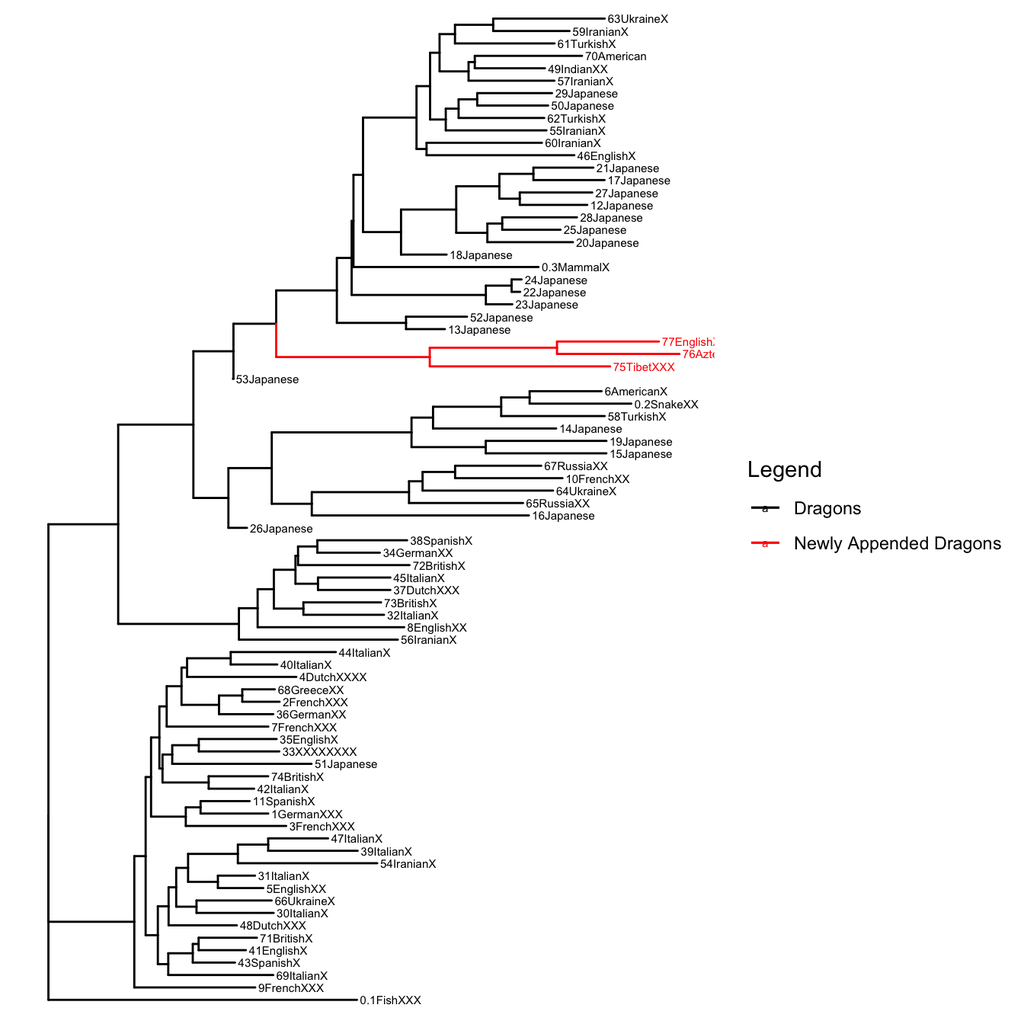

```r
#creating a minimal evolution tree
dragon_tree_me <- fastme.bal(weighted_dist)

#general tree with rectangular layout so labels can be most easily read
tree_base <- ggtree(dragon_tree_me, layout="rectangular") +
  geom_tiplab(size=2)

#Adding a new group with my new dragons so they can be a different colour from the rest
groupOTU(tree_base, c(40, 41, 42)) + aes(colour = group) +
  scale_colour_manual(values = c("black", "red"), labels = c("Dragons", "Newly Appended Dragons"), "Legend")
```

This tree shows all dragons in the Nexus file and the three I added are in red. I added my dragons based on the key given in tutorial but a lot of traits of the other dragons didn’t line up, I attempted to fix the data but was unsure if we could manipulate the other dragon’s data. Overall this is why my the three dragons I added are branched together, because the rest of the dragons did not appear to follow the same code as what was provided to us.